# Preprocessing

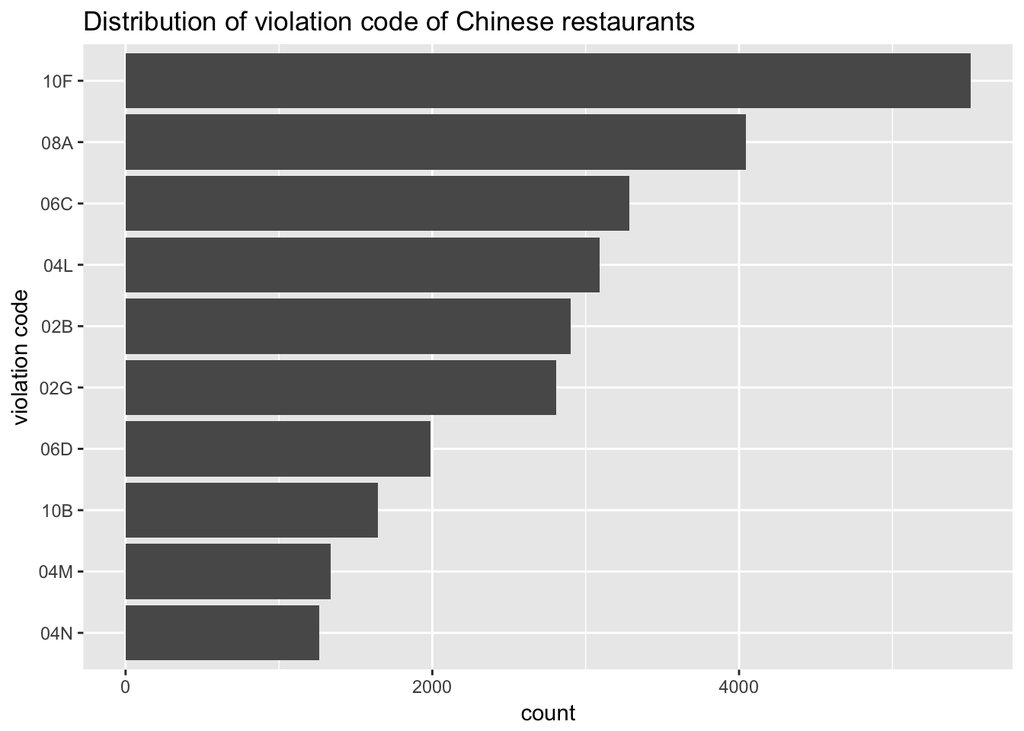

The 10 most common violation types for Chinese restaurants seem to be slightly different from those of the previous two restaurant types. The violation of 04L (Evidence of mice or live mice present in facility’s food and/or non-food areas) is more frequent (in terms of relative frequency). Moreover, the 04M code is violated more than 1000 times and is ranked at top 9. This one is associated with live roaches present in facility’s food and/or non-food areas. So far, our results on the different types of restaurants show us that it would probably be a great idea to look at this report first to avoid the restaurants with roaches and mice.

```r
violation_code_with_restype("Dessert")
```

```
##    VIOLATION.CODE
## 1             10F
## 2             08A
## 3             04L
## 4             06D
## 5             06C
## 6             10B
## 7             04A
## 8             06E
## 9             04N
## 10            04H
##                                                                                                                                                                                                                                                                                   VIOLATION.DESCRIPTION
## 1                       Non-food contact surface improperly constructed. Unacceptable material used. Non-food contact surface or equipment improperly maintained and/or not properly sealed, raised, spaced or movable to allow accessibility for cleaning on all sides, above and underneath the unit.
## 2                                                                                                                                                                    Facility not vermin proof. Harborage or conditions conducive to attracting vermin to the premises and/or allowing vermin to exist.
## 3                                                                                                                                                                                                                       Evidence of mice or live mice present in facility's food and/or non-food areas.
## 4                                                                                                                                                        Food contact surface not properly washed, rinsed and sanitized after each use and following any activity when contamination may have occurred.
## 5                                                                                                                                                                            Food not protected from potential source of contamination during storage, preparation, transportation, display or service.
## 6                                                                    Plumbing not properly installed or maintained; anti-siphonage or backflow prevention device not provided where required; equipment or floor not properly drained; sewage disposal system in disrepair or not functioning properly.
## 7                                                                                                                                                                                                                                Food Protection Certificate not held by supervisor of food operations.
## 8                                                                                                                                                                                                  Sanitized equipment or utensil, including in-use food dispensing utensil, improperly used or stored.
## 9  Filth flies or food/refuse/sewage-associated (FRSA) flies present in facility\032s food and/or non-food areas. Filth flies include house flies, little house flies, blow flies, bottle flies and flesh flies. Food/refuse/sewage-associated flies include fruit flies, drain flies and Phorid flies.
## 10                                                                                                                                                                       Raw, cooked or prepared food is adulterated, contaminated, cross-contaminated, or not discarded in accordance with HACCP plan.
```

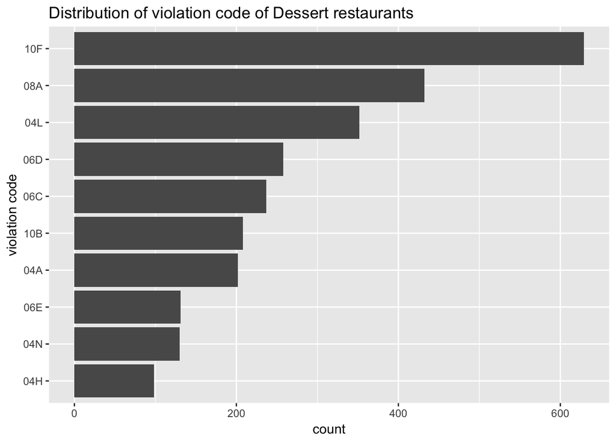